# HS→NAICS Concordance: Many-to-One Correspondence and Granularity Loss

How aggregation to NAICS level conflates distinct clean-tech value chains

Author

Net Zero Industrial Policy Lab · Johns Hopkins SAIS

Published

April 14, 2026

## 1 Overview

**Important**

**The granularity problem:** When multiple clean-tech HS6 codes map to the same NAICS code, any firm-level query on that industry (via S&P Capital IQ Pro, ORBIS, Compustat, etc.) cannot distinguish a solar-panel manufacturer from a wind-turbine manufacturer, or a battery-grade lithium miner from a copper miner. The clean-tech signal collapses into a broad industrial bucket.

| Level | Codes | Note |
| --- | --- | --- |
| Green Dict HS6 | 372.0 | Product-level granularity |
| HS6 matched to NAICS | 349.0 | 94% coverage (Census Schedule B) |
| NAICS 6-digit codes | 107.0 | Industry-level granularity |
| Compression ratio | 3.3 | HS6 per NAICS on average |

## 2 Distribution of HS6 codes per NAICS code

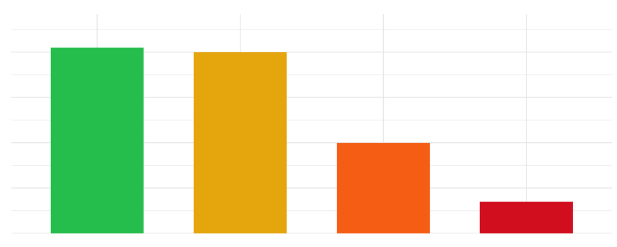

| tier | NAICS codes | HS6 codes affected | Cross-tech NAICS (2+ techs) |
| --- | --- | --- | --- |
| 1 — Unique | 41 | 41 | 7 |
| 2 — Low (2–3) | 40 | 95 | 28 |
| 3 — Medium (4–8) | 20 | 107 | 18 |
| 4 — High (9+) | 7 | 114 | 7 |

- **41 are unique** — clean, one-to-one HS6→NAICS; firm queries are precise.
- **7 are high-severity** (9+ HS6 each) — these aggregate dozens of distinct clean-tech products, spanning multiple technologies, into a single industry bucket.

## 3 Cross-technology aggregation

The most analytically damaging cases are NAICS codes shared by products from **multiple clean technologies.** A single NAICS query returns manufacturers of solar cells, wind bearings, and battery chemicals indiscriminately.

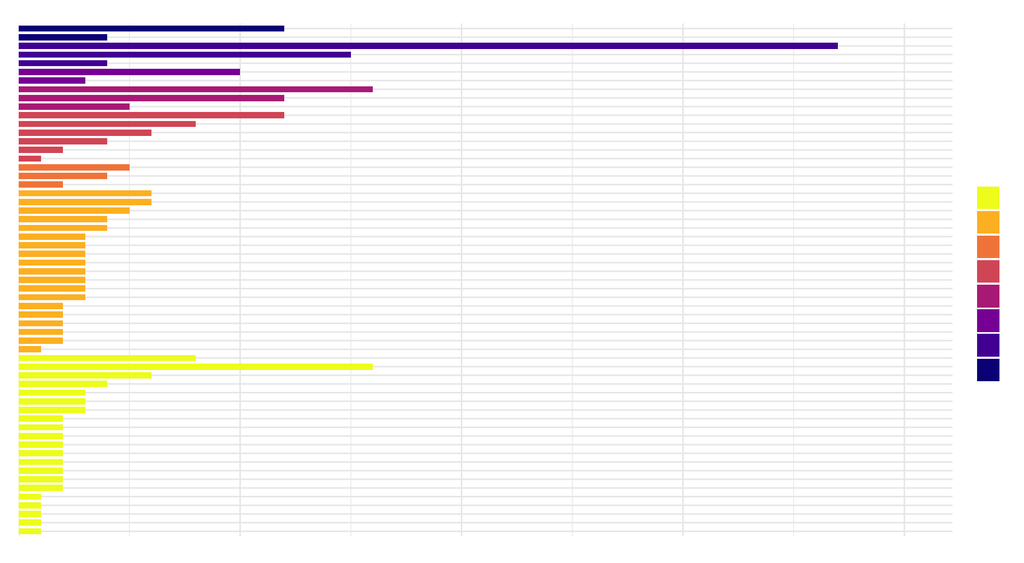

| NAICS | Industry | HS6 | Techs | Technologies | Stages |
| --- | --- | --- | --- | --- | --- |
| 212290 | Other Metal Ore Mining | 12 | 10 | Batteries; Biofuel; Electrolyzers; Geothermal; Heat Pumps; Magnets; Nuclear; Solar; Transmission; Wind | Upstream |
| 212230 | Copper Ore Mining | 4 | 10 | Batteries; Biofuel; Electrolyzers; Geothermal; Heat Pumps; Magnets; Nuclear; Solar; Transmission; Wind | Upstream |
| 325180 | Other Basic Inorganic Chemical Mfg | 37 | 8 | Batteries; Biofuel; Electrolyzers; Geothermal; Magnets; Nuclear; Transmission; Wind | Downstream; Midstream; Upstream |
| 333517 | Die-Cutting Machinery Mfg | 15 | 8 | Batteries; Electrolyzers; Geothermal; Heat Pumps; Magnets; Solar; Transmission; Wind | Downstream; Midstream |
| 333998 | All Other General Purpose Machinery Mfg | 4 | 8 | Batteries; Biofuel; Electrolyzers; Geothermal; Magnets; Nuclear; Solar; Wind | Downstream; Midstream |
| 333248 | All Other Industrial Machinery Mfg | 10 | 7 | Batteries; Electrolyzers; Geothermal; Magnets; Nuclear; Solar; Wind | Downstream; Final Product; Midstream |
| 331313 | Alumina Refining & Primary Aluminum Prod | 3 | 7 | Batteries; Biofuel; Heat Pumps; Magnets; Solar; Transmission; Wind | Downstream; Midstream |
| 331110 | Iron & Steel Mills and Ferroalloy Mfg | 16 | 6 | Batteries; Geothermal; Magnets; Nuclear; Transmission; Wind | Downstream; Final Product; Midstream; Upstream |
| 331410 | Nonferrous Metal Smelting & Refining | 12 | 6 | Batteries; Biofuel; Electrolyzers; Heat Pumps; Solar; Wind | Midstream; Upstream |
| 333912 | Vacuum Pump & Compressor Mfg | 5 | 6 | Batteries; Biofuel; Electrolyzers; Geothermal; Heat Pumps; Wind | Downstream; Midstream |
| 325211 | Plastics Material and Resin Mfg | 12 | 5 | Batteries; Electrolyzers; Geothermal; Solar; Wind | Downstream; Midstream |
| 332410 | Power Boiler & Heat Exchanger Mfg | 8 | 5 | Biofuel; Electrolyzers; Geothermal; Heat Pumps; Nuclear | Downstream; Final Product; Midstream |
| 333310 | Commercial & Industrial Machinery Repair | 6 | 5 | Batteries; Biofuel; Electrolyzers; Geothermal; Wind | Downstream; Midstream |
| 333994 | Industrial Process Furnace & Oven Mfg | 4 | 5 | Geothermal; Magnets; Nuclear; Solar; Transmission | Downstream; Midstream |
| 333241 | Food Product Machinery Mfg | 2 | 5 | Batteries; Biofuel; Electrolyzers; Nuclear; Transmission | Downstream; Midstream |
| 335220 | Household Appliance Mfg | 1 | 5 | Batteries; Magnets; Solar; Transmission; Wind | Downstream; Midstream |
| 333519 | Other Metalworking Machinery Mfg | 5 | 4 | Batteries; Electrolyzers; Geothermal; Transmission | Downstream; Midstream |
| 333992 | Welding & Soldering Equipment Mfg | 4 | 4 | Geothermal; Heat Pumps; Solar; Wind | Downstream; Midstream |
| 212210 | Iron Ore Mining | 2 | 4 | Batteries; Geothermal; Nuclear; Transmission | Upstream |
| 325199 | All Other Basic Organic Chemical Mfg | 6 | 3 | Batteries; Biofuel; Wind | Final Product; Midstream |
| 333415 | A/C & Refrigeration Equipment Mfg | 6 | 3 | Biofuel; Electrolyzers; Heat Pumps | Downstream; Final Product; Midstream |
| 333611 | NAICS 333611 | 5 | 3 | Geothermal; Nuclear; Wind | Downstream; Final Product |
| 325212 | NAICS 325212 | 4 | 3 | Batteries; Electrolyzers; Geothermal | Midstream |
| 335999 | NAICS 335999 | 4 | 3 | Electrolyzers; Magnets; Wind | Downstream; Midstream |
| 212390 | NAICS 212390 | 3 | 3 | Batteries; Geothermal; Heat Pumps | Midstream; Upstream |
| 325110 | NAICS 325110 | 3 | 3 | Batteries; Biofuel; Geothermal | Midstream; Upstream |
| 325998 | NAICS 325998 | 3 | 3 | Biofuel; Geothermal; Solar | Midstream |
| 327910 | NAICS 327910 | 3 | 3 | Geothermal; Magnets; Wind | Downstream; Midstream |
| 331318 | NAICS 331318 | 3 | 3 | Heat Pumps; Transmission; Wind | Midstream |
| 331420 | NAICS 331420 | 3 | 3 | Heat Pumps; Transmission; Wind | Midstream |
| 332999 | NAICS 332999 | 3 | 3 | Batteries; Magnets; Wind | Downstream; Final Product; Midstream |
| 333120 | NAICS 333120 | 3 | 3 | Geothermal; Transmission; Wind | Downstream; Final Product |
| 212323 | NAICS 212323 | 2 | 3 | Geothermal; Heat Pumps; Solar | Upstream |
| 327992 | NAICS 327992 | 2 | 3 | Batteries; Geothermal; Nuclear | Upstream |
| 327999 | NAICS 327999 | 2 | 3 | Batteries; Nuclear; Wind | Midstream |
| 333514 | NAICS 333514 | 2 | 3 | Electrolyzers; Heat Pumps; Magnets | Downstream; Midstream |
| 333914 | NAICS 333914 | 2 | 3 | Biofuel; Electrolyzers; Heat Pumps | Downstream |
| 333413 | NAICS 333413 | 1 | 3 | Biofuel; Electrolyzers; Geothermal | Downstream |
| 332991 | Ball and Roller Bearing Mfg | 8 | 2 | Geothermal; Wind | Midstream |
| 332991 | Ball and Roller Bearing Mfg | 8 | 2 | Geothermal; Wind | Midstream |
| 335312 | Motor and Generator Mfg | 8 | 2 | Solar; Wind | Downstream |
| 334515 | Electricity Measurement Instrument Mfg | 6 | 2 | Batteries; Wind | Downstream; Midstream |
| 326113 | NAICS 326113 | 4 | 2 | Batteries; Solar | Midstream |
| 325120 | NAICS 325120 | 3 | 2 | Biofuel; Solar | Upstream |
| 332996 | NAICS 332996 | 3 | 2 | Geothermal; Wind | Midstream |
| 333515 | NAICS 333515 | 3 | 2 | Geothermal; Wind | Downstream; Midstream |
| 325520 | NAICS 325520 | 2 | 2 | Solar; Wind | Midstream |
| 331210 | NAICS 331210 | 2 | 2 | Geothermal; Wind | Final Product; Midstream |
| 331491 | NAICS 331491 | 2 | 2 | Batteries; Solar | Midstream |
| 331492 | NAICS 331492 | 2 | 2 | Biofuel; Electrolyzers | Midstream |
| 332312 | NAICS 332312 | 2 | 2 | Solar; Wind | Downstream |
| 333993 | NAICS 333993 | 2 | 2 | Batteries; Transmission | Downstream |
| 334416 | NAICS 334416 | 2 | 2 | Transmission; Wind | Final Product; Midstream |
| 335991 | NAICS 335991 | 2 | 2 | Batteries; Wind | Midstream |
| 336310 | NAICS 336310 | 2 | 2 | Geothermal; Wind | Midstream |
| 325130 | NAICS 325130 | 1 | 2 | Biofuel; Electrolyzers | Midstream |
| 325510 | NAICS 325510 | 1 | 2 | Solar; Wind | Midstream |
| 333243 | NAICS 333243 | 1 | 2 | Biofuel; Electrolyzers | Downstream |
| 339991 | NAICS 339991 | 1 | 2 | Geothermal; Wind | Midstream |
| 339999 | NAICS 339999 | 1 | 2 | Magnets; Wind | Downstream; Final Product |

| NAICS | Industry | HS6 codes | Techs | What gets merged |
| --- | --- | --- | --- | --- |
| 325180 | Other Basic Inorganic Chemical Mfg | 37 | 8 | Battery electrolytes, biofuel catalysts, electrolyzer membrane chemicals, geothermal working fluids, rare-earth processing chemicals, nuclear uranium conversion — 8 techs, all calling the same 'inorga… |
| 331110 | Iron & Steel Mills and Ferroalloy Mfg | 16 | 6 | Iron and steel for structural components across Geothermal rigs, Magnet cores, Nuclear reactor vessels, Transmission towers, and Wind turbine towers — 6 techs. |
| 333517 | Die-Cutting Machinery Mfg | 15 | 8 | Die-casting and metal-forming machinery used across Batteries, Electrolyzers, Geothermal, Heat Pumps, Magnets, Solar, Transmission, Wind — 8 techs of process equipment indistinguishable at NAICS level… |
| 212290 | Other Metal Ore Mining | 12 | 10 | All 10 techs share 'Other Metal Ore Mining': lithium, cobalt, manganese (Batteries); rare earths (Magnets); uranium (Nuclear); copper (Transmission/Wind); bauxite (Solar); and more. A single NAICS que… |
| 325211 | Plastics Material and Resin Mfg | 12 | 5 | Plastics/resins: battery separators, electrolyzer membranes, geothermal insulation, solar encapsulants, wind nacelle composites — 5 techs. |
| 331410 | Nonferrous Metal Smelting & Refining | 12 | 6 | Batteries; Biofuel; Electrolyzers; Heat Pumps; Solar; Wind |
| 333248 | All Other Industrial Machinery Mfg | 10 | 7 | Batteries; Electrolyzers; Geothermal; Magnets; Nuclear; Solar; Wind |

## 5 Severity matrix

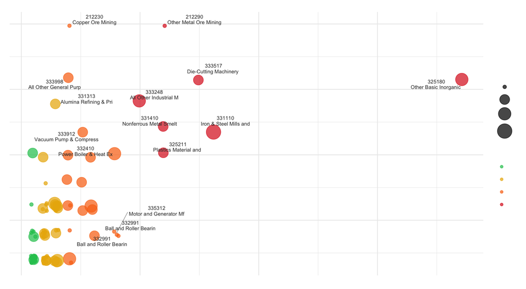

## 6 Stage collapse

Beyond cross-tech contamination, some NAICS codes aggregate products from **different value-chain stages** — meaning firms in that NAICS code might be suppliers of raw materials, midstream processors, or final-product manufacturers, and there is no way to distinguish them using NAICS alone.

| NAICS | Industry | HS6 | Stages | Stages merged | Technologies |
| --- | --- | --- | --- | --- | --- |
| 331110 | Iron & Steel Mills and Ferroalloy Mfg | 16 | 4 | Downstream + Final Product + Midstream + Upstream | Batteries; Geothermal; Magnets; Nuclear; Transmission; Wind |
| 325180 | Other Basic Inorganic Chemical Mfg | 37 | 3 | Downstream + Midstream + Upstream | Batteries; Biofuel; Electrolyzers; Geothermal; Magnets; Nuclear; Transmission; Wind |
| 333248 | All Other Industrial Machinery Mfg | 10 | 3 | Downstream + Final Product + Midstream | Batteries; Electrolyzers; Geothermal; Magnets; Nuclear; Solar; Wind |
| 332410 | Power Boiler & Heat Exchanger Mfg | 8 | 3 | Downstream + Final Product + Midstream | Biofuel; Electrolyzers; Geothermal; Heat Pumps; Nuclear |
| 333415 | A/C & Refrigeration Equipment Mfg | 6 | 3 | Downstream + Final Product + Midstream | Biofuel; Electrolyzers; Heat Pumps |
| 334413 | 334413 | 4 | 3 | Downstream + Final Product + Midstream | Solar |
| 332999 | 332999 | 3 | 3 | Downstream + Final Product + Midstream | Batteries; Magnets; Wind |
| 335910 | 335910 | 3 | 3 | Downstream + Final Product + Midstream | Batteries |
| 333517 | Die-Cutting Machinery Mfg | 15 | 2 | Downstream + Midstream | Batteries; Electrolyzers; Geothermal; Heat Pumps; Magnets; Solar; Transmission; Wind |
| 325211 | Plastics Material and Resin Mfg | 12 | 2 | Downstream + Midstream | Batteries; Electrolyzers; Geothermal; Solar; Wind |
| 331410 | Nonferrous Metal Smelting & Refining | 12 | 2 | Midstream + Upstream | Batteries; Biofuel; Electrolyzers; Heat Pumps; Solar; Wind |
| 325199 | All Other Basic Organic Chemical Mfg | 6 | 2 | Final Product + Midstream | Batteries; Biofuel; Wind |
| 333310 | Commercial & Industrial Machinery Repair | 6 | 2 | Downstream + Midstream | Batteries; Biofuel; Electrolyzers; Geothermal; Wind |
| 334515 | Electricity Measurement Instrument Mfg | 6 | 2 | Downstream + Midstream | Batteries; Wind |
| 333519 | Other Metalworking Machinery Mfg | 5 | 2 | Downstream + Midstream | Batteries; Electrolyzers; Geothermal; Transmission |
| 333611 | 333611 | 5 | 2 | Downstream + Final Product | Geothermal; Nuclear; Wind |
| 333912 | Vacuum Pump & Compressor Mfg | 5 | 2 | Downstream + Midstream | Batteries; Biofuel; Electrolyzers; Geothermal; Heat Pumps; Wind |
| 333992 | Welding & Soldering Equipment Mfg | 4 | 2 | Downstream + Midstream | Geothermal; Heat Pumps; Solar; Wind |
| 333994 | Industrial Process Furnace & Oven Mfg | 4 | 2 | Downstream + Midstream | Geothermal; Magnets; Nuclear; Solar; Transmission |
| 333998 | All Other General Purpose Machinery Mfg | 4 | 2 | Downstream + Midstream | Batteries; Biofuel; Electrolyzers; Geothermal; Magnets; Nuclear; Solar; Wind |
| 335999 | 335999 | 4 | 2 | Downstream + Midstream | Electrolyzers; Magnets; Wind |
| 212390 | 212390 | 3 | 2 | Midstream + Upstream | Batteries; Geothermal; Heat Pumps |
| 325110 | 325110 | 3 | 2 | Midstream + Upstream | Batteries; Biofuel; Geothermal |
| 327910 | 327910 | 3 | 2 | Downstream + Midstream | Geothermal; Magnets; Wind |
| 331313 | Alumina Refining & Primary Aluminum Prod | 3 | 2 | Downstream + Midstream | Batteries; Biofuel; Heat Pumps; Magnets; Solar; Transmission; Wind |
| 333120 | 333120 | 3 | 2 | Downstream + Final Product | Geothermal; Transmission; Wind |
| 333242 | 333242 | 3 | 2 | Downstream + Midstream | Solar |
| 333515 | 333515 | 3 | 2 | Downstream + Midstream | Geothermal; Wind |
| 335311 | 335311 | 3 | 2 | Downstream + Final Product | Transmission |
| 327211 | 327211 | 2 | 2 | Downstream + Midstream | Solar |
| 331210 | 331210 | 2 | 2 | Final Product + Midstream | Geothermal; Wind |
| 333131 | 333131 | 2 | 2 | Downstream + Final Product | Geothermal |
| 333241 | Food Product Machinery Mfg | 2 | 2 | Downstream + Midstream | Batteries; Biofuel; Electrolyzers; Nuclear; Transmission |
| 333514 | 333514 | 2 | 2 | Downstream + Midstream | Electrolyzers; Heat Pumps; Magnets |
| 334416 | 334416 | 2 | 2 | Final Product + Midstream | Transmission; Wind |
| 327215 | 327215 | 1 | 2 | Downstream + Midstream | Solar |
| 335220 | Household Appliance Mfg | 1 | 2 | Downstream + Midstream | Batteries; Magnets; Solar; Transmission; Wind |
| 339999 | 339999 | 1 | 2 | Downstream + Final Product | Magnets; Wind |

## 7 Unmatched HS6 codes: the HS revision gap

Twenty-three green-dictionary HS6 codes have **no match** in the Census Bureau Schedule B → NAICS concordance (2024 edition). These are not data errors — they fall into three structural categories explained below.

| HS6 code | Technology | Role | Stage |
| --- | --- | --- | --- |
| 382490 | Batteries | Product Component | Midstream |
| 390760 | Batteries | Processed Material | Midstream |
| 902780 | Batteries | Process Equipment | Downstream |
| 151000 | Biofuel | Raw Material | Upstream |
| 151490 | Biofuel | Raw Material | Upstream |
| 293290 | Biofuel | Processed Material | Midstream |
| 440110 | Biofuel | Raw Material | Upstream |
| 440130 | Biofuel | Raw Material | Upstream |
| 681510 | Biofuel | Processed Material | Midstream |
| 840619 | Biofuel | Process Equipment | Downstream |
| 854380 | Electrolyzers | Process Equipment | Downstream |
| 851430 | Electrolyzers; Geothermal | Process Equipment | Downstream |
| 846241 | Electrolyzers; Heat Pumps; Transmission | Process Equipment | Downstream |
| 730420 | Geothermal | Product Component | Downstream |
| 845610 | Geothermal | Process Equipment | Downstream |
| 846021 | Geothermal | Process Equipment | Downstream; Midstream |
| 846210 | Geothermal | Process Equipment | Downstream |
| 740110 | Heat Pumps; Transmission; Wind | Processed Material | Midstream |
| 252890 | Nuclear | Raw Material | Upstream |
| 282611 | Nuclear | Processed Material | Midstream |
| 810990 | Nuclear | Processed Material | Midstream |
| 854140 | Solar | Product Component | Downstream |
| 846221 | Wind | Process Equipment | Midstream |

**Why these 23 codes are unmatched**

**Category 1 — HS 2017/2022 revision gap (manual mapping required)**

**These codes must be mapped manually** by inspecting the WCO HS2017→HS2022 correlation table and assigning the successor NAICS code from the new heading. Until that is done, firms dealing in these specific products will be missed by NAICS-based queries.

**Category 2 — Import-only Schedule B positions (not in export concordance)**

The Census `expconcord24.xlsx` is an **export** concordance (Schedule B commodity codes). A small number of HS6 positions — primarily certain process-equipment headings — appear only in US import classifications (HTS, Harmonised Tariff Schedule) and have no Schedule B export equivalent. These products are imported rather than domestically manufactured at a classifiable Schedule B level, so no NAICS production code is assigned.

**Category 3 — Agricultural / biofuel feedstock codes**

Several biofuel feedstock codes (e.g., sugarcane, palm oil, oilseeds) are classified under agricultural chapters (HS 10–15) which the Census Schedule B covers only partially for export purposes. The Census concordance prioritises manufactured goods; primary agricultural commodities used as industrial inputs are underrepresented.

**Implication for S&P Capital IQ Pro matching**

## 8 Implications for firm-level matching

### 8.1 False positives

A query on **NAICS 325180** (Other Basic Inorganic Chemical Manufacturing) returns the entire inorganic chemicals industry. The vast majority of those firms produce acids, pigments, and industrial gases with no clean-tech relevance. The 37 green-dict HS codes mapped here are a small fraction of what that NAICS industry actually produces.

### 8.2 Cross-tech contamination

**NAICS 212290** (Other Metal Ore Mining) covers all 10 clean technologies. Lithium miners, cobalt miners, rare-earth miners, and uranium miners are all in the same bucket. Any country-level analysis of “other metal ore mining” will conflate these entirely different supply chains.

### 8.3 Recommended approach

**R1 — HS6 as primary key where possible**

For databases with HS-level trade identifiers alongside firm records (US Census LFTTD, Indian customs microdata), match directly at HS6. This avoids NAICS aggregation entirely and preserves full product-level granularity.

**R2 — Apply green-dict HS filter as a secondary screen**

When a firm-level database only exposes NAICS codes, retrieve all firms in the NAICS bucket and then cross-reference against the green dictionary HS codes via the firm’s import/export activity (if available). This converts a broad industry sweep into a targeted clean-tech filter.

**R3 — Flag high-severity NAICS codes in any firm-count output**

NAICS **325180, 212290, 333517** each cover 8–10 clean technologies. Any firm count or market-share estimate derived from these codes alone should be labelled as an upper-bound estimate, not a clean-tech-specific figure.

**R4 — The 41 unique-mapping NAICS codes are analysis-ready**

41 NAICS codes have exactly one green-dict HS6 mapped to them. These are safe to use directly in firm queries with high precision: 212220, 212319, 212322, 311225, 325130, 325193, 325311, 325510, 326220, 326299, 327120, 327215, 327310, 327410, 327991, 331314, 332215, 332510, 332618, 332722, 333132, 333243, 333413, 333612, 333613, 333924, 333996, 334412, 334417, 334510, 334511, 334513, 334519, 335220, 335931, 335932, 336330, 336340, 339991, 339999, 910000.

## 9 Data sources

| Source | File | Notes |
| --- | --- | --- |
| NZIPL Green Dictionary | `data/green_dict/green_dictionary.csv` | 372 HS6 codes × 10 techs |
| US Census Bureau | `data/spatial/expconcord24.xlsx` | 2024 Schedule B → NAICS concordance, 9,724 rows |
| HS6→NAICS crosswalk | `data/concordance/hs6_naics_crosswalk.csv` | Built by `scripts/build_data/08c_build_naics_crosswalk.R` |

*Rendered: 2026-04-14*